# Visualizing 14/15 Season NBA Shot-Log

Monday October 17, 2016

## Introduction

NBA shot-log data summarizes the information of every shot during 14-15 regular season. From this data, we can gain information about the shooting selection, performance and play style of every player. This data set can be found at https://www.kaggle.com/dansbecker/nba-shot-logs.

In this work, we are going to visualize this data based on shot distribution and shot accuracy.

Players under study:

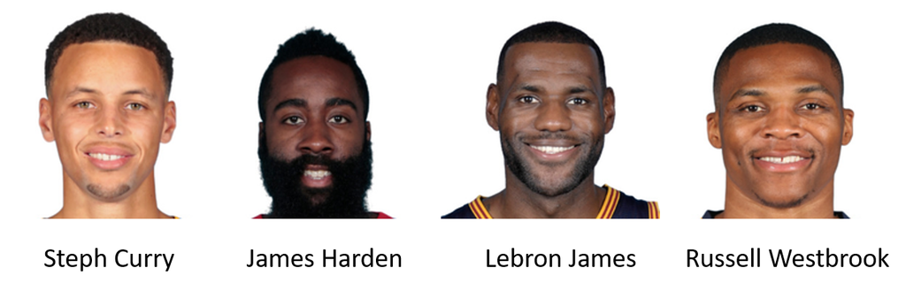

## Contents

- Summary of NBA shot-log data
- Visualization of shot number
- Visualization of shot accuracy
  - Hot hand Phenomenon

## Data Summary

- NAs and bad observations were removed due to lacking of specific pattern.
- Match Variable was splitted and necessary data type conversion were performed.
- Functions were created for subsetting data in order to visualize hot hand phenomenon.

Variables:

| player name | match date | home team | away team | location | match result | shot number |
| --- | --- | --- | --- | --- | --- | --- |
| factor | date | chr | chr | factor | factor | int |

| dribbles | touch time | shot dist | pts type | shot result | close def dist |
| --- | --- | --- | --- | --- | --- |
| int | num | num | factor | factor | factor |

Number of observations after subsetting data:

```
## [1] 3833   20
```

## Visualization of shot number

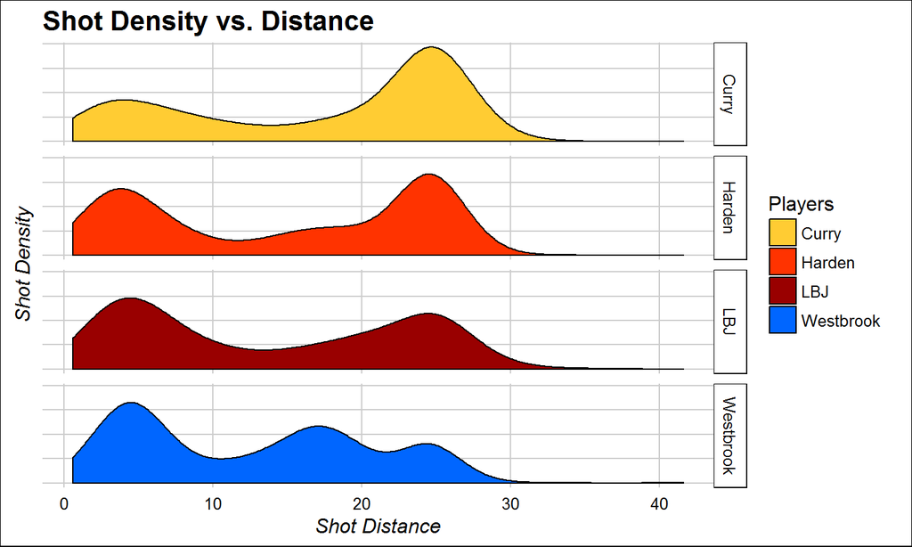

## Visualization of shot number

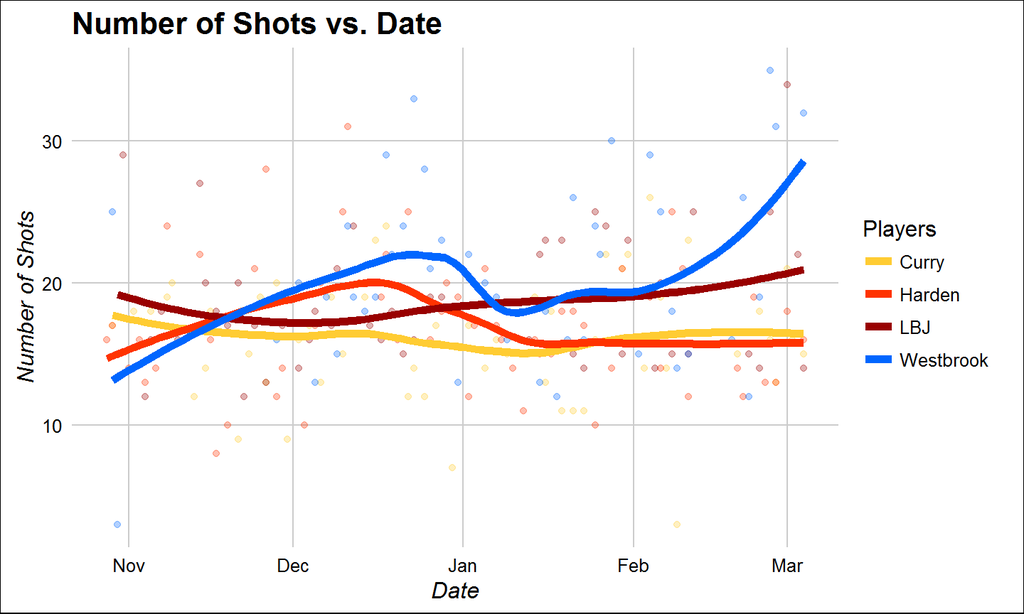

## Visualization of shot number

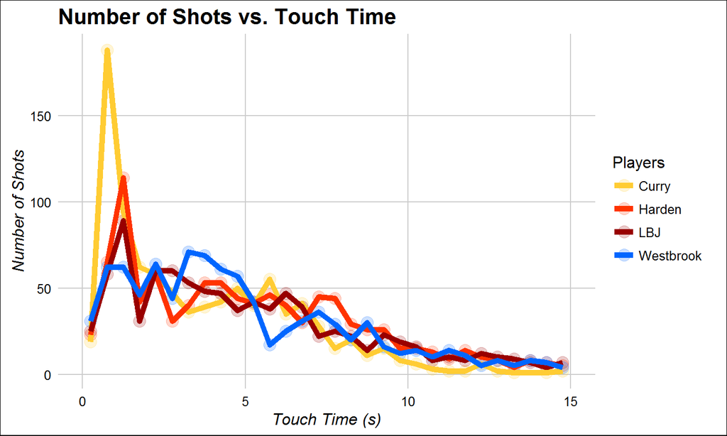

## Visualization of shot number

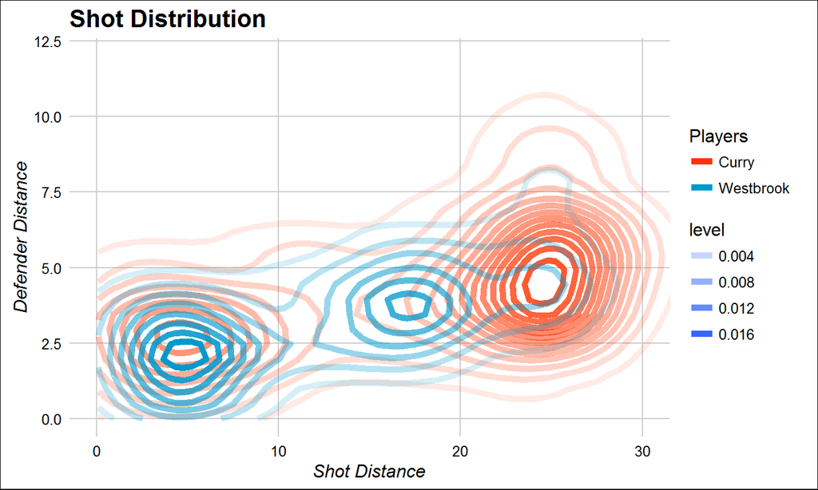

## Visualization of shot number

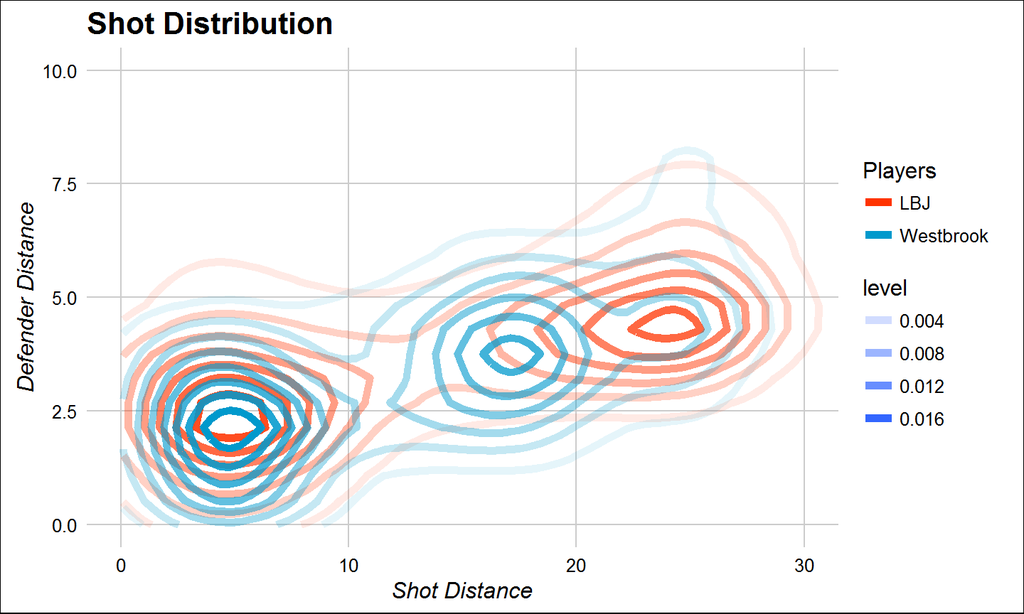

## Visualization of shot number

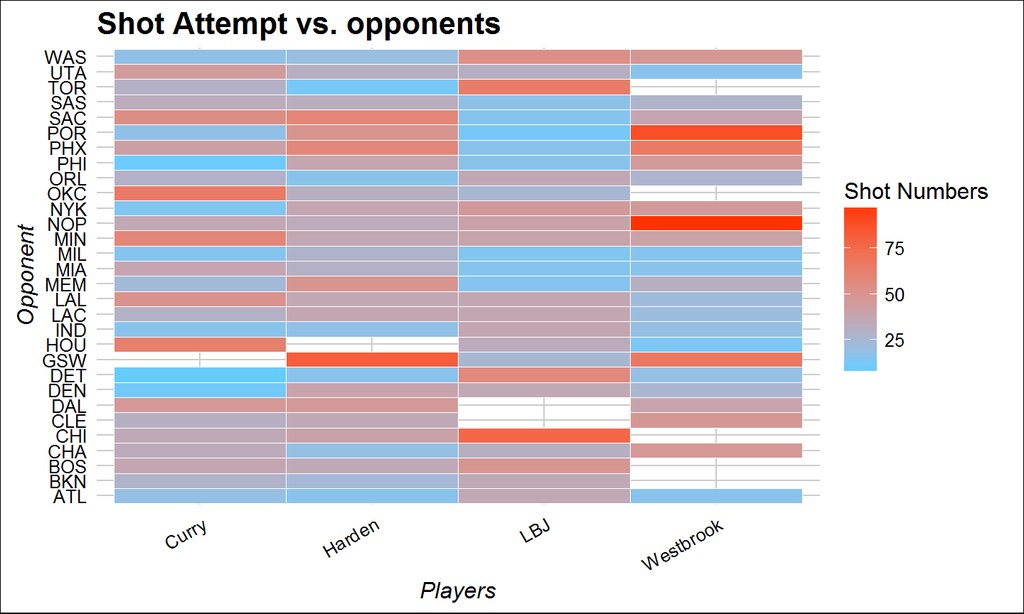

## Visualization of Shot Accuracy

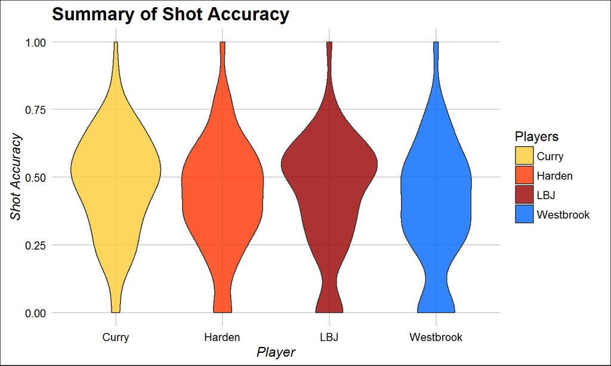

## Visualization of Shot Accuracy

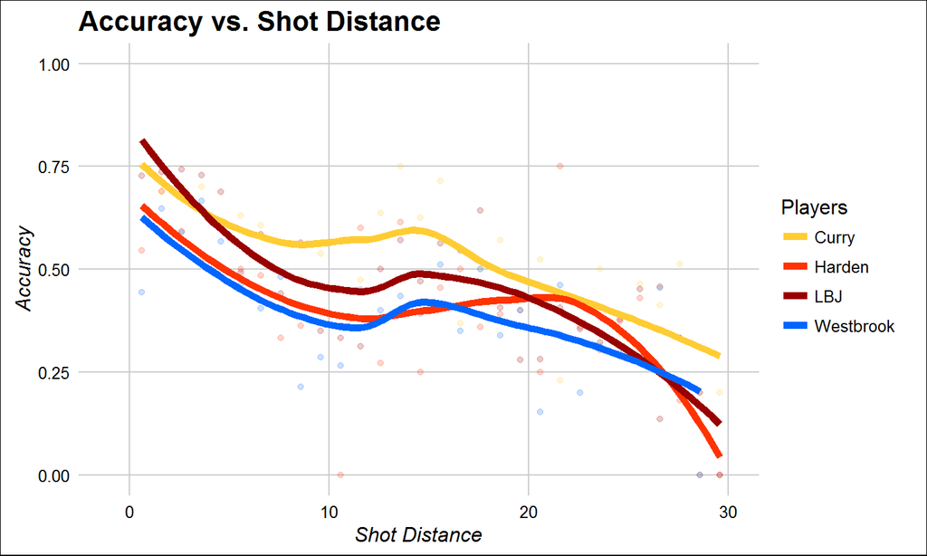

## Visualization of Shot Accuracy

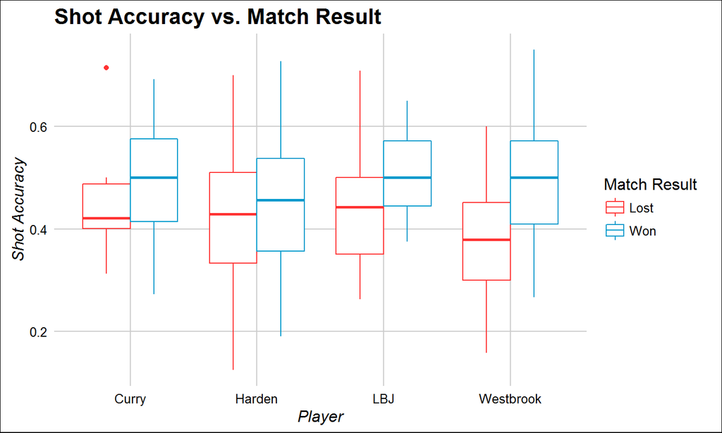

## Visualization of Shot Accuracy

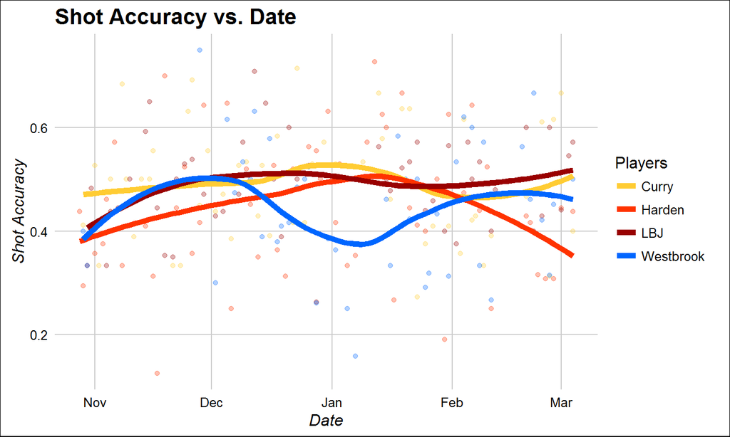

## Visualization of Shot Accuracy

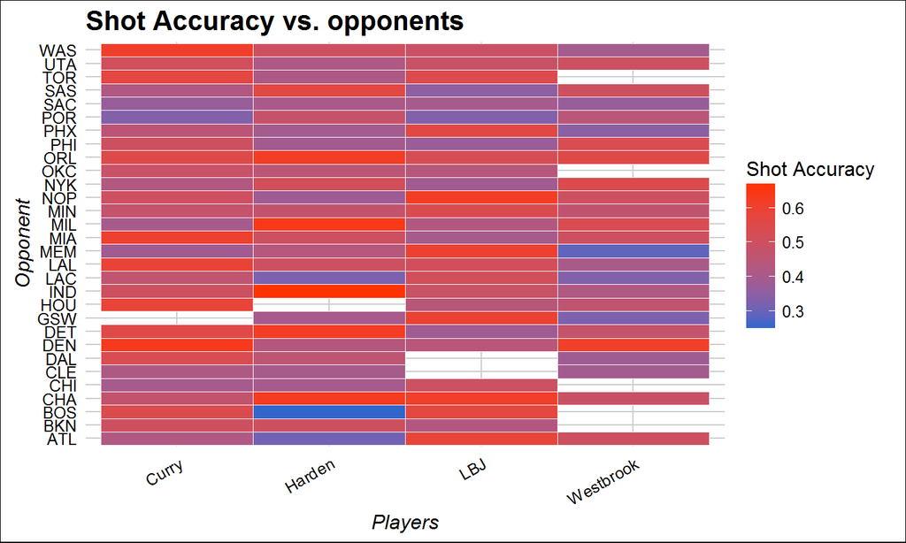

## Hot Hand Phenomenon

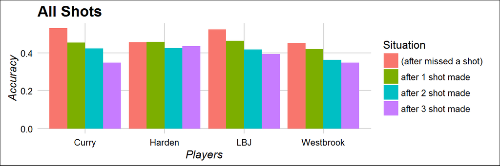

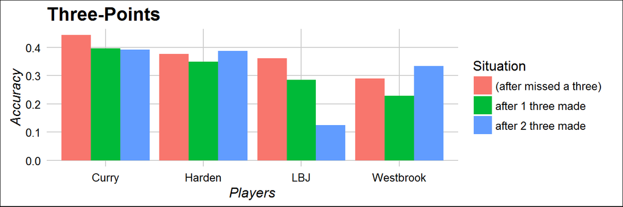

## Conclusion

- From the graphs, we can see:
  - Four stars have dramatically different play style. Steph Curry tends to perform catch and quick release, while Russell Westbrook prefers to attack the rim with ball in hand.
  - Steph Curry and Lebron James have a more stable shot accuracy than Harden and Westbrook.
  - Hitting one shot tends to have negative effect on the next shot.
- An extension of this work can be:
  - Focus on defender side of the data.
  - Perform hypothesis test to the shot accuracy and hot hand data.
  - Prediction the probability of hitting a shot based on machine learning algorithms.